# The Dynamics of Production: From Linear OLS to Nonlinear MLE

Abdullah Shahzad

2025-12-13

# 1 Introduction & Data Preparation

**Objective:** To model the aggregate production function of the German economy (1950–2019). We begin with a standard Cobb-Douglas specification using OLS and progressively refine the model by diagnosing statistical violations (Autocorrelation) and structural limitations (Nonlinearity).

**Data Source:** Penn World Table 10.0 (`pwt10`).

```r
library(pwt10)
library(dplyr)
library(car)
library(lmtest)
library(nlme)

# Filter for Germany and select relevant columns
germany_data <- pwt10.0 %>%
  filter(country == "Germany") %>%
  select(year, rgdpo, emp, rnna) %>%
  rename(gdp = rgdpo, labor = emp, capital = rnna)

# Check structure
str(germany_data)
```

```
## 'data.frame':    70 obs. of  4 variables:
##  $ year   : int  1950 1951 1952 1953 1954 1955 1956 1957 1958 1959 ...
##  $ gdp    : num  358993 397295 433857 471209 512084 ...
##  $ labor  : num  30.9 31.4 32 32.8 33.8 ...
##  $ capital: num  1918305 2051991 2209630 2367171 2552262 ...
```

```r
# Add log transformations for Linear OLS
germany_data <- germany_data %>%
  mutate(log_Y = log(gdp),
         log_L = log(labor),
         log_K = log(capital))

head(germany_data)
```

```
##          year      gdp    labor capital    log_Y    log_L    log_K
## DEU-1950 1950 358992.5 30.85581 1918305 12.79106 3.429325 14.46695
## DEU-1951 1951 397295.1 31.43651 2051991 12.89243 3.447970 14.53432
## DEU-1952 1952 433856.8 32.02428 2209630 12.98047 3.466494 14.60834
## DEU-1953 1953 471209.0 32.83585 2367171 13.06306 3.491521 14.67721
## DEU-1954 1954 512084.1 33.83582 2552262 13.14624 3.521520 14.75249
## DEU-1955 1955 583498.6 34.94468 2808870 13.27680 3.553766 14.84829
```

# 2 The Basic Model: Log-Linear OLS

We estimate a linearized Cobb-Douglas production function:
$$\ln(Y_t) = \ln(A) + \beta_L \ln(L_t) + \beta_K
\ln(K_t) + e_t$$

```r
# First Model (Linear): OLS - Line of Best Fit
model1 <- lm(log_Y ~ log_L + log_K, data = germany_data)
summary(model1)
```

```
##
## Call:
## lm(formula = log_Y ~ log_L + log_K, data = germany_data)
##
## Residuals:
##      Min       1Q   Median       3Q      Max
## -0.24657 -0.10961  0.03782  0.10740  0.17178
##
## Coefficients:
##             Estimate Std. Error t value Pr(>|t|)
## (Intercept)  -4.0343     0.9814  -4.111  0.00011 ***
## log_L         1.1916     0.3994   2.983  0.00397 **
## log_K         0.8715     0.0398  21.899  < 2e-16 ***
## ---
## Signif. codes:  0 '***' 0.001 '**' 0.01 '*' 0.05 '.' 0.1 ' ' 1
##
## Residual standard error: 0.1223 on 67 degrees of freedom
## Multiple R-squared:  0.9681, Adjusted R-squared:  0.9671
## F-statistic:  1017 on 2 and 67 DF,  p-value: < 2.2e-16
```

**Insight:** The coefficients are elasticities.

- $$βL≈1.19 and βK≈0.87 (Total:
  2.06)$$
- This indicates extremely high returns to scale (doubling inputs more than doubles output), which is suspicious for a mature economy.

# 3 Diagnostics & Inference

## 3.1 Multicollinearity Check

Is the high sum of coefficients caused by Labor and Capital being too correlated?

```r
vif(model1)
```

```
##    log_L    log_K
## 3.398327 3.398327
```

**Insight:** A VIF of ~3.4 is well below the threshold of 10. Multicollinearity is not the primary cause of the high estimates.

# 4 Hypothesis Testing

We formally test the Neoclassical assumption of Constant Returns to Scale (CRS):
$$H_0: \beta_L + \beta_K = 1$$

```r
linearHypothesis(model1, "log_L + log_K = 1")
```

```
##
## Linear hypothesis test:
## log_L  + log_K = 1
##
## Model 1: restricted model
## Model 2: log_Y ~ log_L + log_K
##
##   Res.Df    RSS Df Sum of Sq      F   Pr(>F)
## 1     68 1.1276
## 2     67 1.0018  1   0.12573 8.4082 0.005047 **
## ---
## Signif. codes:  0 '***' 0.001 '**' 0.01 '*' 0.05 '.' 0.1 ' ' 1
```

# 5 Breaking Assumptions (GLS)

Standard OLS assumes errors are independent and homoskedastic. Let’s check the residuals.

## 5.1 Visual Inspection

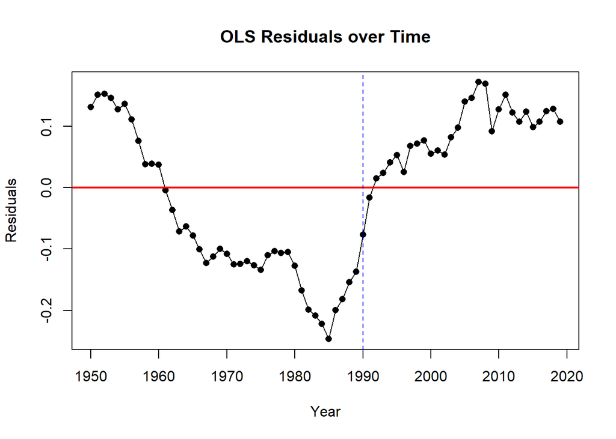

```r
plot(germany_data$year, resid(model1), type="o", pch=16, main="OLS Residuals over Time", ylab="Residuals", xlab="Year")
abline(h=0, col = "red", lwd=2)
abline(v=1990, col = "blue", lty=2) # German Reunification
```

**Insight:** The residuals follow a trend (persistence). Positive errors are followed by positive errors. This indicates Autocorrelation.

## 5.2 Formal Tests

```r
# Heteroskedasticity (Goldfeld-Quandt Test)
gqtest(model1, order.by = ~year, data = germany_data)
```

```
##
##  Goldfeld-Quandt test
##
## data:  model1
## GQ = 0.87689, df1 = 32, df2 = 32, p-value = 0.6438
## alternative hypothesis: variance increases from segment 1 to 2
```

```r
# Autocorrelation (Durbin-Watson Test)
dwtest(model1)
```

```
##
##  Durbin-Watson test
##
## data:  model1
## DW = 0.044502, p-value < 2.2e-16
## alternative hypothesis: true autocorrelation is greater than 0
```

**Insight:**

- GQ Test: p-value > 0.05. We fail to reject homoskedasticity. Variance is stable.
- DW Test: d≈0.04. This is extremely low (far from 2), confirming severe positive autocorrelation.

# 6 The Remedy: Generalized Least Squares (GLS)

We re-estimate using GLS with an AR(1) correlation structure to correct the standard errors and coefficients.

```r
gls_model <- gls(log_Y ~ log_L + log_K, data = germany_data, correlation = corAR1())
summary(gls_model)
```

```
## Generalized least squares fit by REML
##   Model: log_Y ~ log_L + log_K
##   Data: germany_data
##         AIC       BIC   logLik
##   -299.2679 -288.2444 154.6339
##
## Correlation Structure: AR(1)
##  Formula: ~1
##  Parameter estimate(s):
## Phi
##   1
##
## Coefficients:
##                 Value Std.Error   t-value p-value
## (Intercept) -2.130127  554.9746 -0.003838  0.9969
## log_L        1.084381    0.3023  3.586879  0.0006
## log_K        0.782284    0.0836  9.355911  0.0000
##
##  Correlation:
##       (Intr) log_L
## log_L -0.001
## log_K -0.001 -0.532
##
## Standardized residuals:
##           Min            Q1           Med            Q3           Max
## -5.400458e-04 -3.637264e-04 -1.710808e-04  8.588789e-05  2.807829e-04
##
## Residual standard error: 554.9734
## Degrees of freedom: 70 total; 67 residual
```

**Finding:** The coefficients dropped:
$$L:1.19→1.08, K:0.87→0.78$$
OLS was indeed inflating the estimates due to serial correlation.

# 7 Nonlinear Estimation (NLS)

We move beyond the log-linear approximation and estimate the raw multiplicative model directly:
$$Y_t = A
\cdot L_t^{\beta_L} \cdot K_t^{\beta_K} + e_t$$

```r
# Initialize Values from OLS
y_int <- coef(model1)["(Intercept)"]
beta_labor <- coef(model1)["log_L"]
beta_capital <- coef(model1)["log_K"]

# Run NLS (Gauss-Newton Algorithm)
model_nls <- nls(gdp ~ A * (labor^beta_L) * (capital^beta_K),
    data = germany_data,
    start = list(A = exp(y_int), beta_L = beta_labor, beta_K = beta_capital),
    control = nls.control(maxiter = 500))

summary(model_nls)
```

```
##
## Formula: gdp ~ A * (labor^beta_L) * (capital^beta_K)
##
## Parameters:
##         Estimate Std. Error t value Pr(>|t|)
## A      1.409e-04  9.276e-05   1.519    0.133
## beta_L 1.292e+00  2.278e-01   5.672 3.26e-07 ***
## beta_K 1.143e+00  4.706e-02  24.289  < 2e-16 ***
## ---
## Signif. codes:  0 '***' 0.001 '**' 0.01 '*' 0.05 '.' 0.1 ' ' 1
##
## Residual standard error: 182400 on 67 degrees of freedom
##
## Number of iterations to convergence: 77
## Achieved convergence tolerance: 2.353e-06
```

**Insight:** The Capital elasticity (βK) jumped significantly to ~1.14. Because K is numerically large, NLS prioritizes fitting it to minimize absolute errors.

# 8 Forecasting (Scenario Analysis)

**Scenario:** What happens to German GDP (2020–2024) if Labor stays constant but Capital grows at 2% per year?

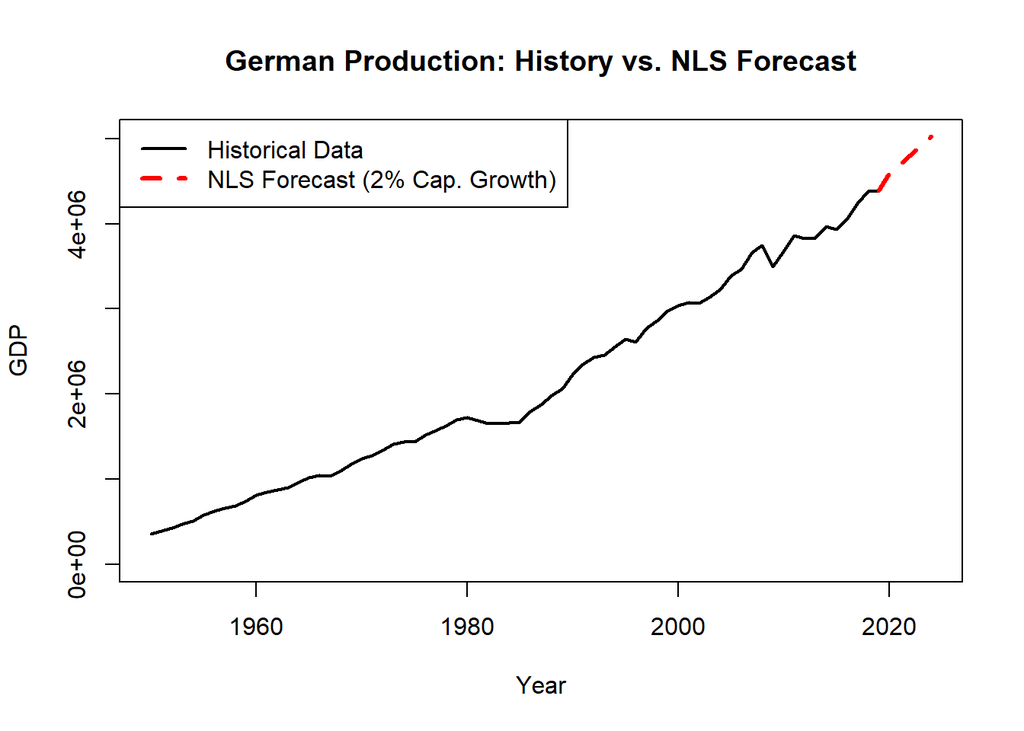

```r
# 1. Create Future Data
last_row <- tail(germany_data, 1)
labor_last <- last_row$labor
capital_last <- last_row$capital
year_last <- last_row$year

year_vals <- (year_last+1):(year_last+5)
labor_vals <- rep(labor_last, 5)
capital_vals <- capital_last * 1.02^(1:5)

future_data <- data.frame(year = year_vals, labor = labor_vals, capital = capital_vals)

# 2. Predict
future_data$predicted_gdp <- predict(model_nls, newdata = future_data)

# 3. Stitch Data for Plotting (Add 2019 point to prevent gap in line)
last_history_row <- data.frame(
  year = year_last,
  labor = labor_last,
  capital = capital_last,
  predicted_gdp = last_row$gdp
)
plot_data <- rbind(last_history_row, future_data)

# 4. Plot
plot(germany_data$year, germany_data$gdp,
     type = "l", col = "black", lwd = 2,
     main = "German Production: History vs. NLS Forecast",
     xlab = "Year", ylab = "GDP",
     xlim = c(1950, max(future_data$year)),
     ylim = c(0, max(plot_data$predicted_gdp)))

lines(plot_data$year, plot_data$predicted_gdp, col = "red", lwd = 3, lty = 2)
legend("topleft", legend = c("Historical Data", "NLS Forecast (2% Cap. Growth)"),
       col = c("black", "red"), lty = c(1, 2), lwd = c(2, 3))
```

# 9 Appendix: “Under the Hood” (Manual Matrix Algebra)

To demonstrate full understanding of the econometric theory, we replicate the estimators manually using matrix algebra.

## 9.1 Manual OLS

$$b = (X'X)^{-1}X'y$$

```r
Y <- matrix(log(germany_data$gdp), ncol = 1)
X <- matrix(c(rep(1, nrow(germany_data)),
              log(germany_data$labor),
              log(germany_data$capital)),
            ncol = 3, byrow = FALSE)

# Estimator
b_hand <- solve(t(X) %*% X) %*% (t(X) %*% Y)
print(t(b_hand))
```

```
##           [,1]     [,2]      [,3]
## [1,] -4.034326 1.191615 0.8714948
```

```r
# Variance
e_hand <- Y - (X %*% b_hand)
SSR <- as.numeric(t(e_hand) %*% e_hand)
T <- nrow(X)
K <- ncol(X)
sigma2_hand <- SSR / (T - K)
cov_b <- sigma2_hand * solve(t(X) %*% X)
se_hand <- sqrt(diag(cov_b))

# T-stats and P-values
t_stats <- b_hand / se_hand
p_values <- 2 * pt(-abs(t_stats), T - K)
results_ols <- cbind(Estimate = b_hand, SE = se_hand, t_stat = t_stats, p_val = p_values)
print(results_ols)
```

```
##                         SE
## [1,] -4.0343259 0.98143575 -4.110637 1.099041e-04
## [2,]  1.1916146 0.39942506  2.983325 3.974934e-03
## [3,]  0.8714948 0.03979566 21.899245 2.999098e-32
```

## 9.2 Manual Hypothesis Testing (F-Test)

$$F = \frac{(Rb - r)' \bigl[ R (X'X)^{-1} R' \bigr] (Rb -
r)}{J\,\hat{\sigma}^2}$$

```r
R <- matrix(c(0, 1, 1), nrow = 1)
r <- 1
J <- 1

discrepancy <- (R %*% b_hand) - r
middle_term <- solve(R %*% solve(t(X) %*% X) %*% t(R))
F_stat_hand <- as.numeric((t(discrepancy) %*% middle_term %*% discrepancy) / (J * sigma2_hand))
p_val_f <- 1 - pf(F_stat_hand, J, T - K)

cat("Manual F-Stat:", F_stat_hand, "\nManual P-Value:", p_val_f)
```

```
## Manual F-Stat: 8.408161
## Manual P-Value: 0.005046704
```

## 9.3 Manual GLS

$$bGLS=(X′Ψ^{−1}X)^{−1}X′Ψ^{−1}y$$

```r
# 1. Estimate rho from OLS residuals
e_t <- e_hand[2:nrow(e_hand)]
e_t_minus_1 <- e_hand[1:(nrow(e_hand)-1)]
rho <- sum(e_t * e_t_minus_1) / sum(e_t_minus_1^2)
print(paste("Rho:", rho))
```

```
## [1] "Rho: 0.974633460046622"
```

```r
# 2. Construct Weight Matrix (Psi Inverse)
exponent_matrix <- abs(outer(1:T, 1:T, "-"))
psi <- rho^exponent_matrix
psi_inv <- solve(psi)

# 3. Estimate Beta GLS
b_gls <- solve(t(X) %*% psi_inv %*% X) %*% (t(X) %*% psi_inv %*% Y)
print(t(b_gls))
```

```
##           [,1]     [,2]      [,3]
## [1,] -2.747601 1.090243 0.8175772
```

## 9.4 Manual NLS (Gauss-Newton Algorithm)

$$βnew=βold+(Z′Z)^{−1}Z′e$$

```r
# Setup
Y_raw <- germany_data$gdp
L_raw <- germany_data$labor
K_raw <- germany_data$capital
beta_current <- c(exp(b_hand[1]), b_hand[2], b_hand[3]) # Start with OLS

# Iteration Loop
tol <- 1e-6
max_iter <- 50
diff <- 100
iter <- 0

while (diff > tol && iter < max_iter) {
  iter <- iter + 1

  A_curr  <- beta_current[1]
  bL_curr <- beta_current[2]
  bK_curr <- beta_current[3]

  # Predictions and Residuals
  pred <- A_curr * (L_raw ^ bL_curr) * (K_raw ^ bK_curr)
  resid_nls <- Y_raw - pred

  # Gradient Matrix Z
  d_A  <- pred / A_curr
  d_bL <- pred * log(L_raw)
  d_bK <- pred * log(K_raw)
  Z <- cbind(d_A, d_bL, d_bK)

  # Update Step (OLS on residuals)
  delta_beta <- solve(t(Z) %*% Z) %*% (t(Z) %*% resid_nls)

  # Update Parameters
  beta_new <- beta_current + as.vector(delta_beta)
  diff <- max(abs(beta_new - beta_current))
  beta_current <- beta_new
}

cat("Converged in", iter, "iterations.\n")
```

```
## Converged in 10 iterations.
```

```r
cat("Manual NLS Parameters:", beta_current)
```

```
## Manual NLS Parameters: 0.0001409111 1.292357 1.143053
```